# (Ford GoBike System Data Exploartion)

## Preliminary Wrangling

Ford GoBike is a public bicycle sharing system in the san francisco bay area, it's the first regional and large scale bicycle sharing system deployed in California. it has over 2600 biycycles in over 250 stations.

This dataset contains over 500,000+ bike trips recorded.

I will try to explore the data visually and understand relation between different features.

```python
# import all packages and set plots to be embedded inline
import numpy as np
import pandas as pd
import matplotlib.pyplot as plt
import seaborn as sb

%matplotlib inline
```

For my dataset, I download the data of three consucitive months from last year manually.

I will read them one by one and merge them into one dataset to analyze.

```python
## Read in the data from the recent 3 months
df08 = pd.read_csv("201808-fordgobike-tripdata.csv")
df07 = pd.read_csv("201807-fordgobike-tripdata.csv")
df06 = pd.read_csv("201806-fordgobike-tripdata.csv")
```

```python
## concating the dataframes into one dataframe

df = pd.concat([df08,df07,df06])
```

### Overview of the data:

```python
df.info()
```

```
<class 'pandas.core.frame.DataFrame'>
Int64Index: 587352 entries, 0 to 195967
Data columns (total 16 columns):
duration_sec               587352 non-null int64
start_time                 587352 non-null object
end_time                   587352 non-null object
start_station_id           579195 non-null float64
start_station_name         579195 non-null object
start_station_latitude     587352 non-null float64
start_station_longitude    587352 non-null float64
end_station_id             579195 non-null float64
end_station_name           579195 non-null object
end_station_latitude       587352 non-null float64
end_station_longitude      587352 non-null float64
bike_id                    587352 non-null int64
user_type                  587352 non-null object
member_birth_year          551404 non-null float64
member_gender              551521 non-null object
bike_share_for_all_trip    587352 non-null object
dtypes: float64(7), int64(2), object(7)
memory usage: 76.2+ MB
```

```python
df.head()
```

|  | duration_sec | start_time | end_time | start_station_id | start_station_name | start_station_latitude | start_station_longitude | end_station_id | end_station_name | end_station_latitude | end_station_longitude | bike_id | user_type | member_birth_year | member_gender | bike_share_for_all_trip |
| --- | --- | --- | --- | --- | --- | --- | --- | --- | --- | --- | --- | --- | --- | --- | --- | --- |
| 0 | 69465 | 2018-08-31 19:18:08.6130 | 2018-09-01 14:35:54.0640 | 3.0 | Powell St BART Station (Market St at 4th St) | 37.786375 | -122.404904 | 3.0 | Powell St BART Station (Market St at 4th St) | 37.786375 | -122.404904 | 813 | Customer | NaN | NaN | No |
| 1 | 60644 | 2018-08-31 21:40:01.7490 | 2018-09-01 14:30:46.4470 | 50.0 | 2nd St at Townsend St | 37.780526 | -122.390288 | 50.0 | 2nd St at Townsend St | 37.780526 | -122.390288 | 1964 | Subscriber | 1990.0 | Male | No |
| 2 | 57922 | 2018-08-31 20:04:28.1630 | 2018-09-01 12:09:50.8240 | 17.0 | Embarcadero BART Station (Beale St at Market St) | 37.792251 | -122.397086 | 30.0 | San Francisco Caltrain (Townsend St at 4th St) | 37.776598 | -122.395282 | 535 | Customer | 1997.0 | Male | No |
| 3 | 82573 | 2018-08-31 13:07:14.9020 | 2018-09-01 12:03:28.2600 | 19.0 | Post St at Kearny St | 37.788975 | -122.403452 | 34.0 | Father Alfred E Boeddeker Park | 37.783988 | -122.412408 | 3080 | Customer | 2000.0 | Female | No |
| 4 | 57677 | 2018-08-31 19:48:45.1980 | 2018-09-01 11:50:03.1560 | 3.0 | Powell St BART Station (Market St at 4th St) | 37.786375 | -122.404904 | 3.0 | Powell St BART Station (Market St at 4th St) | 37.786375 | -122.404904 | 132 | Customer | NaN | NaN | No |

```python
df.member_gender.value_counts()
```

```
Male      400022
Female    142286
Other       9213
Name: member_gender, dtype: int64
```

```python
df.shape
```

```
(587352, 16)
```

```python
df.describe()
```

|  | duration_sec | start_station_id | start_station_latitude | start_station_longitude | end_station_id | end_station_latitude | end_station_longitude | bike_id | member_birth_year |
| --- | --- | --- | --- | --- | --- | --- | --- | --- | --- |
| count | 587352.000000 | 579195.000000 | 587352.000000 | 587352.000000 | 579195.000000 | 587352.000000 | 587352.000000 | 587352.000000 | 551404.000000 |
| mean | 895.729978 | 119.199182 | 37.768222 | -122.347390 | 118.177177 | 37.768330 | -122.346982 | 2239.735700 | 1983.537983 |
| std | 2521.030803 | 99.262075 | 0.106441 | 0.231851 | 99.682565 | 0.106356 | 0.231612 | 1224.365398 | 10.335090 |
| min | 61.000000 | 3.000000 | 37.312854 | -122.473658 | 3.000000 | 37.280000 | -122.473658 | 11.000000 | 1881.000000 |
| 25% | 353.000000 | 31.000000 | 37.771058 | -122.410662 | 30.000000 | 37.771104 | -122.408531 | 1201.000000 | 1978.000000 |
| 50% | 565.000000 | 89.000000 | 37.781270 | -122.395936 | 88.000000 | 37.781650 | -122.395526 | 2321.000000 | 1986.000000 |
| 75% | 897.000000 | 186.000000 | 37.797320 | -122.279352 | 186.000000 | 37.798014 | -122.282497 | 3289.000000 | 1991.000000 |
| max | 85967.000000 | 367.000000 | 45.510000 | -73.570000 | 367.000000 | 45.510000 | -73.570000 | 4466.000000 | 2000.000000 |

```python
## Checking for duplicate rows
df.duplicated().sum()
```

```
0
```

```python
## Checking for missing values
df.isna().sum()
```

```
duration_sec                   0
start_time                     0
end_time                       0
start_station_id            8157
start_station_name          8157
start_station_latitude         0
start_station_longitude        0
end_station_id              8157
end_station_name            8157
end_station_latitude           0
end_station_longitude          0
bike_id                        0
user_type                      0
member_birth_year          35948
member_gender              35831
bike_share_for_all_trip        0
dtype: int64
```

```python
## Creating copy of the dataframe to clean

df_clean = df.copy()
```

I believe that I will be using the gender and birth columns for my analysis, and seeing that they only account for ~7% of the rows I will just drop them completely.

```python
## dropping null values
df_clean = df_clean.dropna()
```

```python
## asserting
df_clean.isna().sum()
```

```
duration_sec               0
start_time                 0
end_time                   0
start_station_id           0
start_station_name         0
start_station_latitude     0
start_station_longitude    0
end_station_id             0
end_station_name           0
end_station_latitude       0
end_station_longitude      0
bike_id                    0
user_type                  0
member_birth_year          0
member_gender              0
bike_share_for_all_trip    0
dtype: int64
```

```python
## Change data columns to datetime type

df_clean.start_time = pd.to_datetime(df_clean.start_time)
df_clean.end_time = pd.to_datetime(df_clean.end_time)
```

```python
df_clean.info()
```

```
<class 'pandas.core.frame.DataFrame'>
Int64Index: 543474 entries, 1 to 195967
Data columns (total 16 columns):
duration_sec               543474 non-null int64
start_time                 543474 non-null datetime64[ns]
end_time                   543474 non-null datetime64[ns]
start_station_id           543474 non-null float64
start_station_name         543474 non-null object
start_station_latitude     543474 non-null float64
start_station_longitude    543474 non-null float64
end_station_id             543474 non-null float64
end_station_name           543474 non-null object
end_station_latitude       543474 non-null float64
end_station_longitude      543474 non-null float64
bike_id                    543474 non-null int64
user_type                  543474 non-null object
member_birth_year          543474 non-null float64
member_gender              543474 non-null object
bike_share_for_all_trip    543474 non-null object
dtypes: datetime64[ns](2), float64(7), int64(2), object(5)
memory usage: 70.5+ MB
```

```python
df_clean.head()
```

|  | duration_sec | start_time | end_time | start_station_id | start_station_name | start_station_latitude | start_station_longitude | end_station_id | end_station_name | end_station_latitude | end_station_longitude | bike_id | user_type | member_birth_year | member_gender | bike_share_for_all_trip |
| --- | --- | --- | --- | --- | --- | --- | --- | --- | --- | --- | --- | --- | --- | --- | --- | --- |
| 1 | 60644 | 2018-08-31 21:40:01.749 | 2018-09-01 14:30:46.447 | 50.0 | 2nd St at Townsend St | 37.780526 | -122.390288 | 50.0 | 2nd St at Townsend St | 37.780526 | -122.390288 | 1964 | Subscriber | 1990.0 | Male | No |
| 2 | 57922 | 2018-08-31 20:04:28.163 | 2018-09-01 12:09:50.824 | 17.0 | Embarcadero BART Station (Beale St at Market St) | 37.792251 | -122.397086 | 30.0 | San Francisco Caltrain (Townsend St at 4th St) | 37.776598 | -122.395282 | 535 | Customer | 1997.0 | Male | No |
| 3 | 82573 | 2018-08-31 13:07:14.902 | 2018-09-01 12:03:28.260 | 19.0 | Post St at Kearny St | 37.788975 | -122.403452 | 34.0 | Father Alfred E Boeddeker Park | 37.783988 | -122.412408 | 3080 | Customer | 2000.0 | Female | No |
| 5 | 76960 | 2018-08-31 13:07:46.348 | 2018-09-01 10:30:26.644 | 19.0 | Post St at Kearny St | 37.788975 | -122.403452 | 285.0 | Webster St at O'Farrell St | 37.783521 | -122.431158 | 3056 | Customer | 2000.0 | Female | No |
| 6 | 37897 | 2018-08-31 21:44:54.176 | 2018-09-01 08:16:31.897 | 157.0 | 65th St at Hollis St | 37.846784 | -122.291376 | 151.0 | 53rd St at Hollis St | 37.836182 | -122.287180 | 1123 | Customer | 1992.0 | Male | No |

```python
df_clean.user_type.value_counts()
```

```
Subscriber    472317
Customer       71157
Name: user_type, dtype: int64
```

```python
## Checking count of stations.
df_clean.start_station_id.value_counts().shape
```

```
(307,)
```

```python
## Checking if the starting stations count match with ending station count
df_clean.end_station_id.value_counts().shape
```

```
(307,)
```

### Adding potentially useful columns:

```python
## Adding age column

df_clean["age"] = 2018-df_clean.member_birth_year.astype(int) ## note: 2018 is the date of the dataset
```

```python
## assessing
df_clean.age.head(5)
```

```
1    28
2    21
3    18
5    18
6    26
Name: age, dtype: int32
```

```python
from datetime import date
import calendar

type(date.today())
type(df_clean.start_time)
```

```
pandas.core.series.Series
```

```python
## Adding day of week column
df_clean["day"] = df_clean.start_time.dt.day_name()
```

```python
## assessing
df_clean.head()
```

|  | duration_sec | start_time | end_time | start_station_id | start_station_name | start_station_latitude | start_station_longitude | end_station_id | end_station_name | end_station_latitude | end_station_longitude | bike_id | user_type | member_birth_year | member_gender | bike_share_for_all_trip | age | day |
| --- | --- | --- | --- | --- | --- | --- | --- | --- | --- | --- | --- | --- | --- | --- | --- | --- | --- | --- |
| 1 | 60644 | 2018-08-31 21:40:01.749 | 2018-09-01 14:30:46.447 | 50.0 | 2nd St at Townsend St | 37.780526 | -122.390288 | 50.0 | 2nd St at Townsend St | 37.780526 | -122.390288 | 1964 | Subscriber | 1990.0 | Male | No | 28 | Friday |
| 2 | 57922 | 2018-08-31 20:04:28.163 | 2018-09-01 12:09:50.824 | 17.0 | Embarcadero BART Station (Beale St at Market St) | 37.792251 | -122.397086 | 30.0 | San Francisco Caltrain (Townsend St at 4th St) | 37.776598 | -122.395282 | 535 | Customer | 1997.0 | Male | No | 21 | Friday |
| 3 | 82573 | 2018-08-31 13:07:14.902 | 2018-09-01 12:03:28.260 | 19.0 | Post St at Kearny St | 37.788975 | -122.403452 | 34.0 | Father Alfred E Boeddeker Park | 37.783988 | -122.412408 | 3080 | Customer | 2000.0 | Female | No | 18 | Friday |
| 5 | 76960 | 2018-08-31 13:07:46.348 | 2018-09-01 10:30:26.644 | 19.0 | Post St at Kearny St | 37.788975 | -122.403452 | 285.0 | Webster St at O'Farrell St | 37.783521 | -122.431158 | 3056 | Customer | 2000.0 | Female | No | 18 | Friday |
| 6 | 37897 | 2018-08-31 21:44:54.176 | 2018-09-01 08:16:31.897 | 157.0 | 65th St at Hollis St | 37.846784 | -122.291376 | 151.0 | 53rd St at Hollis St | 37.836182 | -122.287180 | 1123 | Customer | 1992.0 | Male | No | 26 | Friday |

```python
## Creating time in hours column for starting time and ending time.

df_clean["start_hour"] = df_clean.start_time.dt.hour

df_clean["end_hour"] = df_clean.end_time.dt.hour
```

```python
df_clean.head()
```

|  | duration_sec | start_time | end_time | start_station_id | start_station_name | start_station_latitude | start_station_longitude | end_station_id | end_station_name | end_station_latitude | end_station_longitude | bike_id | user_type | member_birth_year | member_gender | bike_share_for_all_trip | age | day | start_hour | end_hour |
| --- | --- | --- | --- | --- | --- | --- | --- | --- | --- | --- | --- | --- | --- | --- | --- | --- | --- | --- | --- | --- |
| 1 | 60644 | 2018-08-31 21:40:01.749 | 2018-09-01 14:30:46.447 | 50.0 | 2nd St at Townsend St | 37.780526 | -122.390288 | 50.0 | 2nd St at Townsend St | 37.780526 | -122.390288 | 1964 | Subscriber | 1990.0 | Male | No | 28 | Friday | 21 | 14 |
| 2 | 57922 | 2018-08-31 20:04:28.163 | 2018-09-01 12:09:50.824 | 17.0 | Embarcadero BART Station (Beale St at Market St) | 37.792251 | -122.397086 | 30.0 | San Francisco Caltrain (Townsend St at 4th St) | 37.776598 | -122.395282 | 535 | Customer | 1997.0 | Male | No | 21 | Friday | 20 | 12 |
| 3 | 82573 | 2018-08-31 13:07:14.902 | 2018-09-01 12:03:28.260 | 19.0 | Post St at Kearny St | 37.788975 | -122.403452 | 34.0 | Father Alfred E Boeddeker Park | 37.783988 | -122.412408 | 3080 | Customer | 2000.0 | Female | No | 18 | Friday | 13 | 12 |
| 5 | 76960 | 2018-08-31 13:07:46.348 | 2018-09-01 10:30:26.644 | 19.0 | Post St at Kearny St | 37.788975 | -122.403452 | 285.0 | Webster St at O'Farrell St | 37.783521 | -122.431158 | 3056 | Customer | 2000.0 | Female | No | 18 | Friday | 13 | 10 |
| 6 | 37897 | 2018-08-31 21:44:54.176 | 2018-09-01 08:16:31.897 | 157.0 | 65th St at Hollis St | 37.846784 | -122.291376 | 151.0 | 53rd St at Hollis St | 37.836182 | -122.287180 | 1123 | Customer | 1992.0 | Male | No | 26 | Friday | 21 | 8 |

### Overview of the new columns

```python
df_clean.age.describe()
```

```
count    543474.000000
mean         34.508823
std          10.360140
min          18.000000
25%          27.000000
50%          32.000000
75%          40.000000
max         137.000000
Name: age, dtype: float64
```

```python
df_clean.start_hour.describe()
```

```
count    543474.000000
mean         13.584613
std           4.769123
min           0.000000
25%           9.000000
50%          14.000000
75%          17.000000
max          23.000000
Name: start_hour, dtype: float64
```

```python
df_clean.end_hour.describe()
```

```
count    543474.000000
mean         13.742431
std           4.794799
min           0.000000
25%           9.000000
50%          15.000000
75%          18.000000
max          23.000000
Name: end_hour, dtype: float64
```

```python
df_clean.day.value_counts()
```

```
Tuesday      92062
Friday       91121
Thursday     90688
Wednesday    89401
Monday       88274
Saturday     48581
Sunday       43347
Name: day, dtype: int64
```

```python
df_clean.columns
```

```
Index(['duration_sec', 'start_time', 'end_time', 'start_station_id',
       'start_station_name', 'start_station_latitude',
       'start_station_longitude', 'end_station_id', 'end_station_name',
       'end_station_latitude', 'end_station_longitude', 'bike_id', 'user_type',
       'member_birth_year', 'member_gender', 'bike_share_for_all_trip', 'age',
       'day', 'start_hour', 'end_hour'],
      dtype='object')
```

```python
df_clean.shape
```

```
(543474, 20)
```

### What is the structure of your dataset?

The Data:

Trip Duration (seconds)

Start/End Time and Date

Start/End Station ID

Start/End Station Name

Start/End Station Latitude

Start/End Station Longitude

Bike ID

User Type (Subscriber or Customer – “Subscriber” = Member or “Customer” = Casual)

Member Year of Birth and Gender

Derived Columns:

Memeber Age

Trip Day of The Week

Starting/Ending Hour of the trip

### What is/are the main feature(s) of interest in your dataset?

Understading why duration of each trip differ seems interesting, since intuitively it seems very dependent on other variables from our dataset.

We'll will try to understand why duration differs from one trip to another by using other variables.

### What features in the dataset do you think will help support your investigation into your feature(s) of interest?

I suspect the age and gender of memebers will effect the duration, also I could see the day of the week effecting the duration.

The User Type(Subscriber or Customer) might effect the duration of each trip.

## Univariate Exploration

I will start by observeing the distribution of the main interest variables:

### Duration of trip

```python
df.duration_sec.describe()
```

```
count    587352.000000
mean        895.729978
std        2521.030803
min          61.000000
25%         353.000000
50%         565.000000
75%         897.000000
max       85967.000000
Name: duration_sec, dtype: float64
```

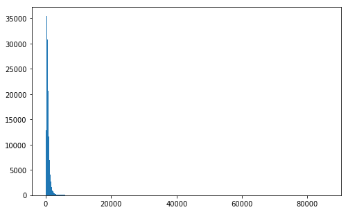

```python
plt.figure(figsize=[8, 5])
binsize = 50
bin_edges = np.arange(0,df_clean["duration_sec"].max()+binsize,binsize)
plt.hist(data=df_clean, x='duration_sec',bins = bin_edges);
```

75% of the trips are below 900 seconds, and the max trip duration is around 86000 seconds which creates this distribution.

There is a really long tail, I will preform a logarthimic scalling and try to plot it again.

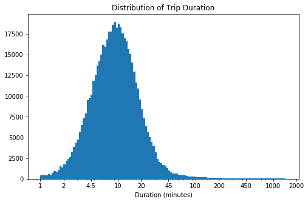

```python
log_binsize = 0.025
bins = 10 ** np.arange(0, np.log10(df_clean['duration_sec'].max()/60)+log_binsize, log_binsize)

plt.figure(figsize=[8, 5])
plt.title("Distribution of Trip Duration")
plt.hist(data = df_clean, x =df_clean["duration_sec"]/60, bins = bins)
plt.xscale('log')
ticks = [1,2,4.5,10,20,45,100,200,450,1000,2000] ## ~ 10^0 10^0.33 10^0.66 ...
plt.xticks(ticks, ticks)
plt.xlabel('Duration (minutes)')
plt.show()
```

Now it looks more normally distributed with a peak at around 10 minutes, but there seems to be a tail after 200 minutes, could be inconsistent outliers?

more than 200 minutetrips seems very extreme, it could effect the outcome we get about the general pouplation I will get rid of trips that exceed 200 minutes, but I will save them for some potential anaylsis, and see if they share common traits later on.

```python
df_duration_over200 = df_clean[df_clean["duration_sec"]/60 >= 200];

df_clean = df_clean[df_clean["duration_sec"]/60 <200]
```

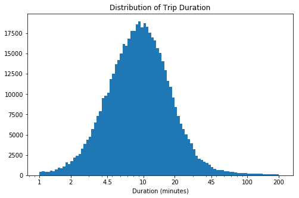

```python
log_binsize = 0.025
bins = 10 ** np.arange(0, np.log10(df_clean['duration_sec'].max()/60)+log_binsize, log_binsize)

plt.figure(figsize=[8, 5])
plt.title("Distribution of Trip Duration")
plt.hist(data = df_clean, x =df_clean["duration_sec"]/60, bins = bins)
plt.xscale('log')
ticks = [1,2,4.5,10,20,45,100,200] ## ~ 10^0 10^0.33 10^0.66 ...
plt.xticks(ticks, ticks)
plt.xlabel('Duration (minutes)')
plt.show()
```

Now it looks like a proper normal distribution, with a peak at ~10 minute trips.

Now lets look at some other features of our data

### Genedr

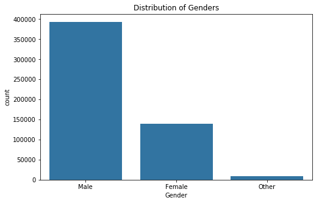

```python
plt.figure(figsize=[8, 5])
plt.title("Distribution of Genders")
base_color = sb.color_palette()[0]
ax = sb.countplot(data = df_clean, x = 'member_gender', color = base_color);
plt.ybins = [2,2,2,]
plt.xlabel("Gender");
```

Most trips in our dataset are by males.

### User Type

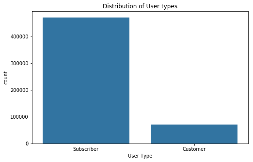

```python
plt.figure(figsize=[8, 5])
plt.title("Distribution of User types")
sb.countplot(data = df_clean, x = 'user_type', color = base_color);
plt.xlabel("User Type");
```

Most of the users are subscriber, it would be interesting to see differences between them later.

### Age

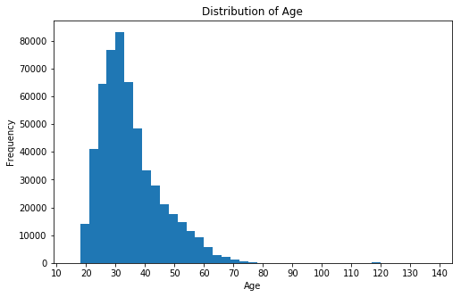

```python
plt.figure(figsize=[8, 5])
plt.title("Distribution of Age")
binsize = 3
bin_edges = np.arange(df_clean["age"].min()-binsize,df_clean["age"].max()+binsize,binsize)
ticks = np.arange(10,df_clean["age"].max()+10,10)
plt.hist(data=df_clean, x='age',bins = bin_edges);
plt.xticks(ticks);
plt.xlabel("Age");
plt.ylabel("Frequency");
```

Seems like the age distribution is almost nomral, but there seem to be a right long tail.

Does the data that is represented by the right of the tail form a big portion of the data?

```python
df_clean.age.describe()
```

```
count    541872.000000
mean         34.510807
std          10.359161
min          18.000000
25%          27.000000
50%          32.000000
75%          40.000000
max         137.000000
Name: age, dtype: float64
```

```python
sum(df_clean["age"]>75) ## These values skewd the graph, and they only are a small portion of the data
```

```
669
```

```python
df_clean = df_clean[df_clean["age"] <75]
```

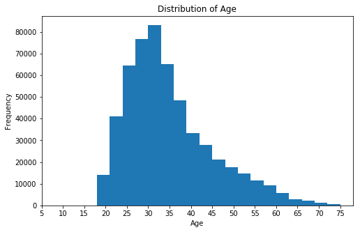

```python
plt.figure(figsize=[8, 5])
plt.title("Distribution of Age")
binsize = 3
bin_edges = np.arange(df_clean["age"].min()-binsize,df_clean["age"].max()+binsize,binsize)
ticks = np.arange(5,df_clean["age"].max()+5,5)
plt.hist(data=df_clean, x='age',bins = bin_edges);
plt.xticks(ticks);
plt.xlabel("Age");
plt.ylabel("Frequency");
```

That looks better, still can't say it's normally distrubited there seems to be a right tail.

The peak age frequency is between 30 and 35

### Day of the Week

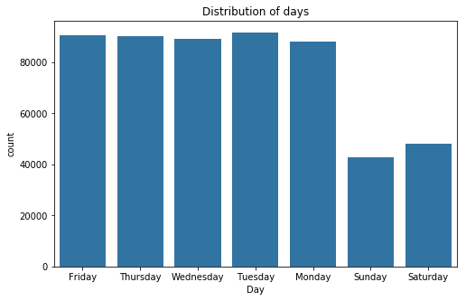

```python
plt.figure(figsize=[8, 5])
plt.title("Distribution of days")
sb.countplot(data = df_clean, x = 'day', color = base_color);
plt.xlabel("Day");
```

Looks like weekdays account for most of the trips, as sunday and saturday have the least amount of trips.

That could be due people using the system to go to work mainly.

### Start/End Hour

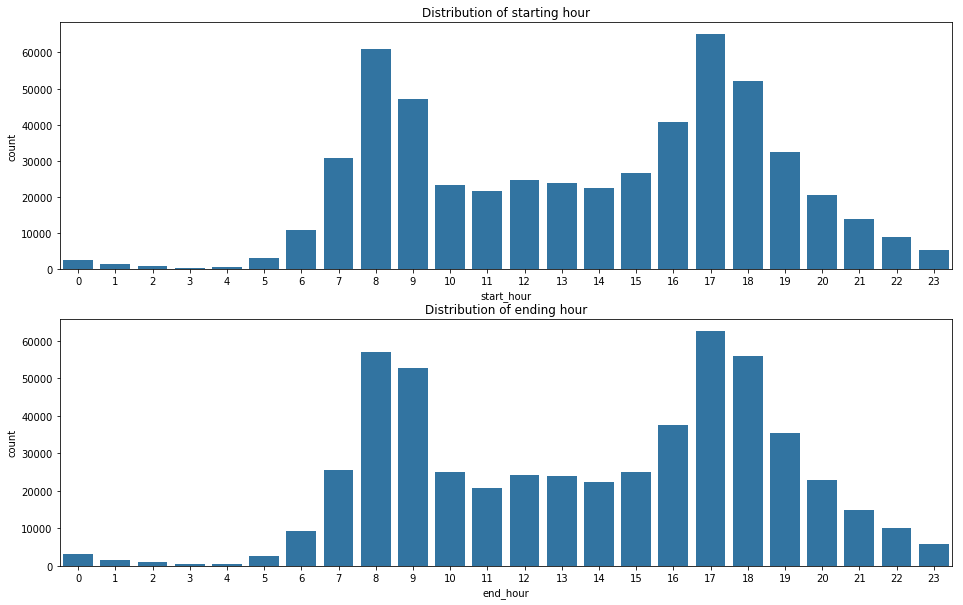

```python
plt.figure(figsize = [16, 10])



plt.subplot(2, 1, 1)
plt.title("Distribution of starting hour")
sb.countplot(data = df_clean, x = 'start_hour', color = base_color);
plt.subplot(2, 1, 2)
plt.title("Distribution of ending hour")
sb.countplot(data = df_clean, x = 'end_hour', color = base_color);
```

The start and end hour are both a bimodal distribution, with the first peak at 8 am and the second peak at 5 pm. Seems like a typcial job hours: 9AM-5PM.

```python
## Saving clean data for future use
df_clean.to_csv('fordGoBike_clean', index=False)
```

### Discuss the distribution(s) of your variable(s) of interest. Were there any unusual points? Did you need to perform any transformations?

The duation of trips covered a wide range of values, I had to preform a log transformation to normalize the distribution. there was a peak at around 10 minutes trip druation.

### Of the features you investigated, were there any unusual distributions? Did you perform any operations on the data to tidy, adjust, or change the form of the data? If so, why did you do this?

In the duration feature, there were some extreme outliers like trips that exceed 3 hours, I dropped these trips as they effect the general pouplation when they are account for a small portion, but before I dropped them I saved them into a seperate dataframe to see if I could find interesting findings about them.

The age distribution of users was roughly right skewed with a peak in the 30 to 35 years range, outliers were removed (older than 75)

## Bivariate Exploration

> In this section, investigate relationships between pairs of variables in your data. Make sure the variables that you cover here have been introduced in some fashion in the previous section (univariate exploration).

```python
df_clean.columns
```

```
Index(['duration_sec', 'start_time', 'end_time', 'start_station_id',
       'start_station_name', 'start_station_latitude',
       'start_station_longitude', 'end_station_id', 'end_station_name',
       'end_station_latitude', 'end_station_longitude', 'bike_id', 'user_type',
       'member_birth_year', 'member_gender', 'bike_share_for_all_trip', 'age',
       'day', 'start_hour', 'end_hour'],
      dtype='object')
```

```python
numeric_vars = ['duration_sec', 'age', 'start_hour', 'end_hour']
```

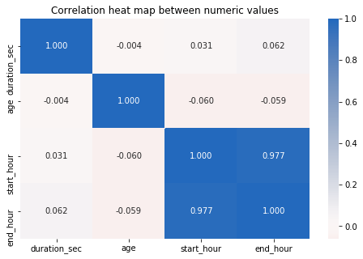

```python
plt.figure(figsize = [8, 5])
sb.heatmap(df_clean[numeric_vars].corr(), annot = True, fmt = '.3f',
           cmap = 'vlag_r', center = 0)
plt.title("Correlation heat map between numeric values")
plt.show()
```

The heat map indicate that there isn't much linear coorealtion between the numeric data, except for the stat_hour and end_hour which are coorelated by definition.

Lets look at the plot matrix

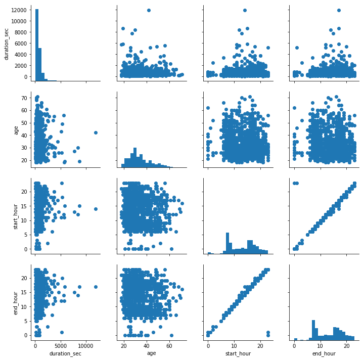

```python
samples = np.random.choice(df_clean.shape[0], 1000, replace = False)
samp = df_clean.loc[samples,:]

g = sb.PairGrid(data = samp, vars = numeric_vars)
g = g.map_diag(plt.hist, bins = 20);
g.map_offdiag(plt.scatter);
```

the plots look clustered. This is probably due to the differnt scales between the data.

#### I will try to now plot duration against different numeric variables but this time converting to aproprite units.

### Duration vs Age

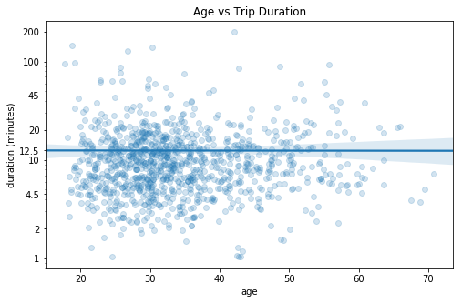

```python
plt.figure(figsize=[8, 5])
plt.title("Age vs Trip Duration")
ax = sb.regplot(data = samp, x = 'age', y = samp["duration_sec"]/60, x_jitter = 0.5,scatter_kws = {'alpha' : 1/5})
plt.yscale('log')
ticksWithMean = [1,2,4.5,10,12.5,20,45,100,200] ## ~ 10^0 10^0.33 10^0.66 ...
plt.yticks(ticksWithMean, ticksWithMean);
plt.ylabel("duration (minutes)");
```

There doesn't seem to be any coorelation between age and duartion.

The mean seems to be around ~12.5 minutes trips for every age group.

### Duration vs Start Hour

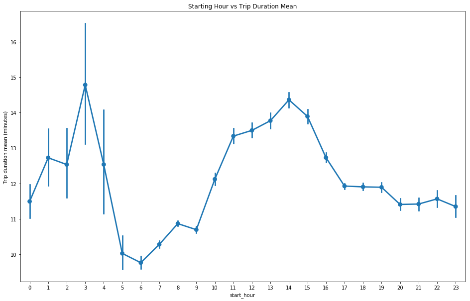

```python
plt.figure(figsize=[16, 10])
plt.title("Starting Hour vs Trip Duration Mean")
sb.pointplot(data = df_clean, x = 'start_hour', y = df_clean["duration_sec"]/60, lines="")
plt.ylabel("Trip duration mean (minutes) ");
```

There seem to be some correlation between start hour and trip duration mean, with a peak at 3am in trip duration and 2 pm in trip duration.

Note that there is relative low sample size for hours before 5am as seen by the high variblity in that interval.

### Duration vs Catagorical Variables

I will first create a new column that have the log of the duration in minutes.

```python
df_clean["log10_duration_min"] = np.log10(df_clean.duration_sec/60)
```

### Duration vs User Type

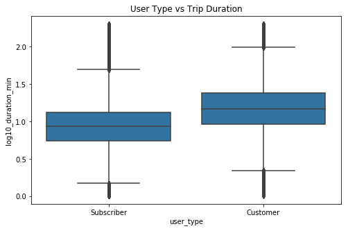

```python
plt.figure(figsize=[8, 5])
plt.title("User Type vs Trip Duration")
default_color = sb.color_palette()[0]
sb.boxplot(data=df_clean, x="user_type",y="log10_duration_min", color = default_color);
```

```python
df_clean.groupby(["user_type"]).median().log10_duration_min
```

```
user_type
Customer      1.168792
Subscriber    0.936179
Name: log10_duration_min, dtype: float64
```

```python
## Calculate exact minutes
print("Normal customers median",10**1.16)
print("Subscribers median", 10**0.93)
```

```
Normal customers median 14.454397707459272
Subscribers median 8.511380382023766
```

It seems like normal customers have on average longer trips than subscribers.

with 14.4 median for normal customers (minutes)

and 8.5 median for subscribers (minutes)

### Duration vs Gender

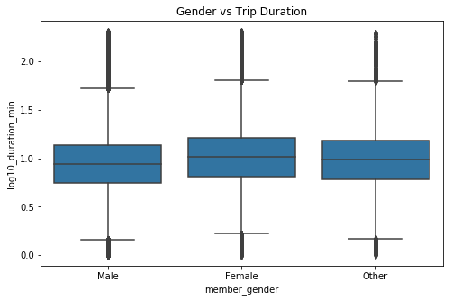

```python
plt.figure(figsize=[8, 5])
plt.title("Gender vs Trip Duration")
default_color = sb.color_palette()[0]
sb.boxplot(data=df_clean, x="member_gender",y="log10_duration_min", color = default_color);
```

#### As seen from the boxplot females seem to have longer trips than males.

```python
df_clean.groupby(["member_gender"]).median().log10_duration_min
```

```
member_gender
Female    1.016337
Male      0.942834
Other     0.984527
Name: log10_duration_min, dtype: float64
```

```python
## Calculate the exact minutes
print("Female median: ", 10**1.01)
print("Male median: ", 10**0.94)
```

```
Female median:  10.232929922807541
Male median:  8.709635899560805
```

### Duration of Trip vs Day of the Week

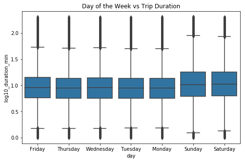

```python
plt.figure(figsize=[8, 5])
plt.title("Day of the Week vs Trip Duration")
default_color = sb.color_palette()[0]
sb.boxplot(data=df_clean, x="day",y="log10_duration_min", color = default_color);
```

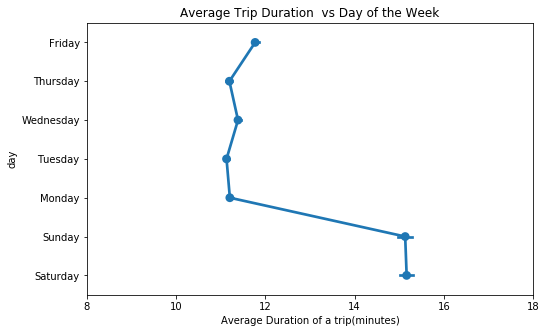

```python
plt.figure(figsize=[8, 5])
plt.title("Average Trip Duration  vs Day of the Week")
sb.pointplot(data = df_clean, x = df_clean["duration_sec"]/60, y = 'day')
plt.xticks([8,10,12,14,16,18])
plt.xlabel("Average Duration of a trip(minutes)");
```

An interesting obvservation from the boxplot and the pointplot is that worweeks (top 5 on the plot) have on average less trip duration than weekends(bottom 2), with around ~11 minutes average at workweeks and ~15 minute average on weekends.

### User Type and Day of the Week

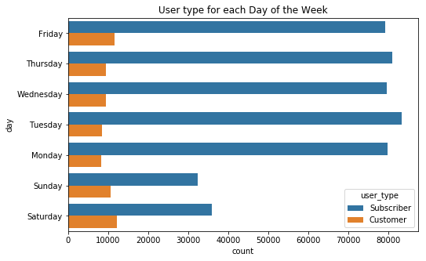

```python
plt.figure(figsize=[8, 5])
plt.title("User type for each Day of the Week")
ax = sb.countplot(data = df_clean, y = 'day', hue = 'user_type')
```

We've established before that subscribers account for a bigger portion of bikers in this dataset so this is not very suprising at a first glance.

But notice in the weekends normal customers count rise while subscribers count fall, which could indicate that subscribers use the bikes mostly for commute to work.

### Talk about some of the relationships you observed in this part of the investigation. How did the feature(s) of interest vary with other features in the dataset?

Catagorical values on the other hand seemed to have an impact on trip duration.

When plotting Trip Duration vs User Type it showed the non-subscribers had longer trip duration, with a medain of ~15 minutes while subscribers had a medain of ~9 minutes.

When plotting Trip Duration vs Gender it showed that Females have slightly logner trips than males, with a median of ~10.3 minutes while males had a median of ~8.7 minutes trip duration.

When plotting Trip Duration vs Day of the Week it showed that trips on weekends had on average longer trip duration than workweeks. ~15 minute average for weekends, and ~11 minutes average for workweeks.

When ploting Trip duration vs Start Hour of the trip, we see that trip duration is at peak at 2pm with a good enough sample size.

With tuesday having lowest trip duration average.

### Did you observe any interesting relationships between the other features (not the main feature(s) of interest)?

User type and the day of week had interesting relationships.

## Multivariate Exploration

First I am interested in seeing the relation between the duration of the trip and the day of the week along with user type.

### Trip Duration vs User Type vs Day of the Week

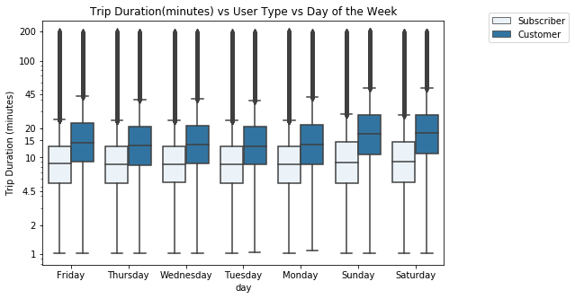

```python
plt.figure(figsize=[8, 5])
default_color = sb.color_palette()[0]
ax = sb.boxplot(data=df_clean, x="day",y=df_clean["duration_sec"]/60, color = default_color,hue="user_type");
plt.yscale('log')
ticks = [1,2,4.5,10,15,20,45,100,200] ## ~ 10^0 10^0.33 10^0.66 ...
plt.yticks(ticks, ticks)
ax.legend(bbox_to_anchor=(1.1, 1.05));
plt.ylabel("Trip Duration (minutes)")
plt.title("Trip Duration(minutes) vs User Type vs Day of the Week");
```

Trip duration for subscribers is roughly the same along the week, but trip duration forn non-subscribers is roughly the same in workweeks but increase in weekends, very interesting.

### Trip Duration vs Gender vs Day of the Week

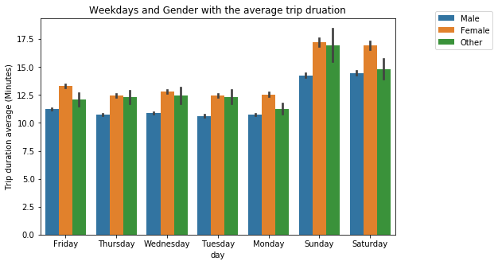

```python
plt.figure(figsize=[8, 5])
ax = sb.barplot(data = df_clean, x = 'day', y = df_clean["duration_sec"]/60, hue = 'member_gender')
ax.legend(loc = 8, ncol = 3, framealpha = 1, title = 'member_gender')
ax.legend(bbox_to_anchor=(1.1, 1.05));
plt.ylabel("Trip duration average (Minutes)")
plt.title("Weekdays and Gender with the average trip druation");
```

It seems like females rides are longer than that of males in everyday of the week.

Also as seen before, the trip duration increases in the weekends in general

### Trip Duration vs User Type vs Gender

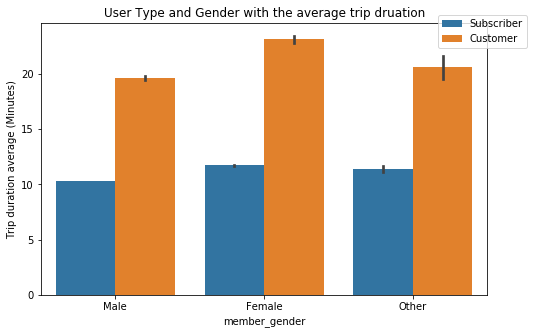

```python
plt.figure(figsize=[8, 5])
ax = sb.barplot(data = df_clean, x = 'member_gender', y = df_clean["duration_sec"]/60, hue = 'user_type')
ax.legend(loc = 8, ncol = 3, framealpha = 1, title = 'user_type')
ax.legend(bbox_to_anchor=(1.1, 1.05));
plt.ylabel("Trip duration average (Minutes)")
plt.title("User Type and Gender with the average trip druation");
```

As seen before, females ride longer than males, non-subscribers have higher trip duration than females.

What follows from that the female non_subscribers have the highest trip durations.

### Star Hour vs Gender vs Trip Duration vs User Type

```python
df_male_female = df_clean[df_clean["member_gender"]!="Other"] ## Only female and males are needed for this plot
                                                              ## As they account for most of the data
                                                              ## one less color make the graph way clearer
df_sub = df_male_female[df_male_female["user_type"]=="Subscriber"]
df_nonsub = df_male_female[df_male_female["user_type"]!="Subscriber"]
```

```python
df_nonsub = df_nonsub.iloc[1:,:] ## drop first row to make the plot easier, so the first row contains a male for the color hue down
```

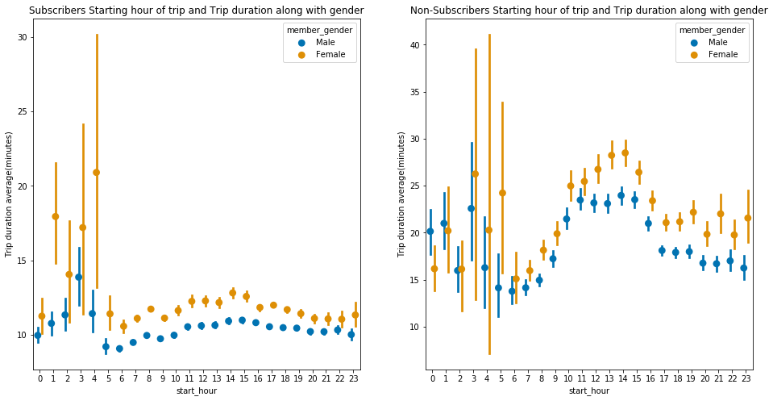

```python
fig, ax = plt.subplots(ncols = 2, figsize = [16,8])
sb.pointplot(data = df_sub, x = 'start_hour', y = df_sub["duration_sec"]/60, hue = 'member_gender',
           palette = 'colorblind', linestyles = '', dodge = 0.3,ax=ax[0])
ax[0].set_title('Subscribers Starting hour of trip and Trip duration along with gender')
ax[0].set_ylabel('Trip duration average(minutes)')
ax[0].set_yticklabels([],minor = True)

sb.pointplot(data = df_nonsub, x = 'start_hour', y = df_nonsub["duration_sec"]/60, hue = 'member_gender',
           palette = 'colorblind', linestyles = '', dodge = 0.3,ax=ax[1])
ax[1].set_title('Non-Subscribers Starting hour of trip and Trip duration along with gender')
ax[1].set_ylabel('Trip duration average(minutes)')
ax[1].set_yticklabels([],minor = True)




plt.show();
```

Subscribers and non subscriber have similar distrubiton, but non subscribers have longer trip duration as established before.

If we consider the starting hour of the day is at 6 am, then we can observe a slow rise of trip duration until we reach a peak at 2 pm of trip duration and then starting falling down.

### Talk about some of the relationships you observed in this part of the investigation. Were there features that strengthened each other in terms of looking at your feature(s) of interest?

Subscribers trip durations are fairly consistent throughout the days of the week, but non-subscribers trip durations increase in the weekend in a clear way.

It was shown in the Bivariate Exploration that trip durations increase in general at the weekends, but with multivariate exploration it showed what was the reason behind it, as subscribers had roughly no impact on the increase but only the non-subscribers.

Females have longer trip duration than males in everyday of the week.

### Were there any interesting or surprising interactions between features?

Non-subscribers have longer trip duration than that of subscribers.

Trip duration in weekend increases, but thats due to non-subscribers mostly while subscirbers have consistent trip duration throughout the week.

given that a person is a subscirber means that he is less likely to ride on the weekend, and there is an increase of numbers of non-subscribers who ride at the weekend when compared to the workweeks non-subscriber count.